# Speciall caeses Hierachical models and the GRM

Hannah M. Heister, Casper J. Albers and Marieke E. Timmerman

2026-11-04

Some tests have a hierarchical structure, such that the full test measures a certain latent trait, while subtests of the tests measure unique latent traits. Then it can be assumed that items hold information regarding a unique latent trait and a general latent trait. When applying IRT-based continous norming this hierarchical structure can be modeled with a hierachical IRT model. The norming is performed similar to unidimensional IRT-based norming but the hierachical structure has to be acknoleged in model checking. This vingette focuses on the special considerations for hierarchical test. For a general example about IRT-based norming using IRTnorm we refere to the vingette for unidimensional models.

```r
library(IRTnorm)
library(ggplot2)
data("HOdata")
```

For this example we assume we know which model fits the data best. How to select the best model is described in the 2PLnorm vingette.

```r
infoHO <- estimate_norming_model(irt_model = "HO1PLnorm-C",
                               raw_data = HOdata,
                               age_variable = "age",
                               item_variables = 1:90,
                               itemD = rep(1:3, each = 30),
                               age_model = "poly",
                               poly_mean = 3,
                               poly_sd = 2,
                               seed = 1234,
                               iter_warmup = 500,
                               iter_sampling =500,
                               extract_stan_object = TRUE)
```

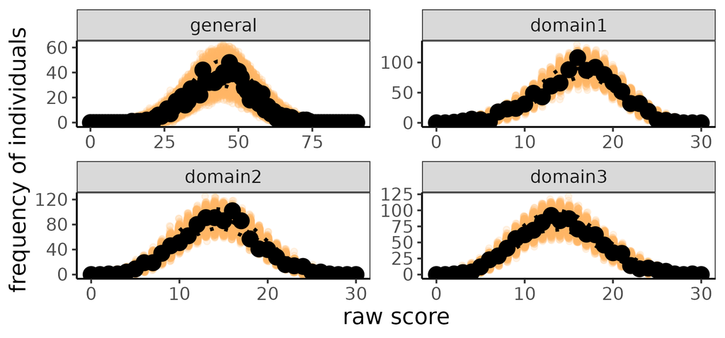

```r
NC_info <- raw_score_ppc(fit_info = infoHO)
visual_raw_score_ppc(NC_info)
```

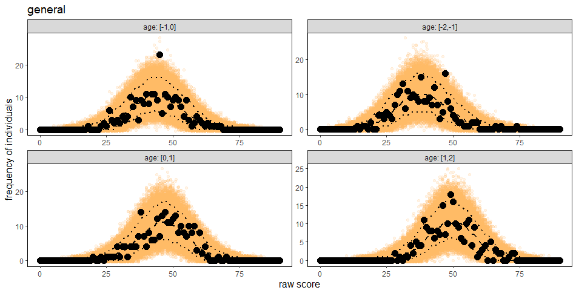

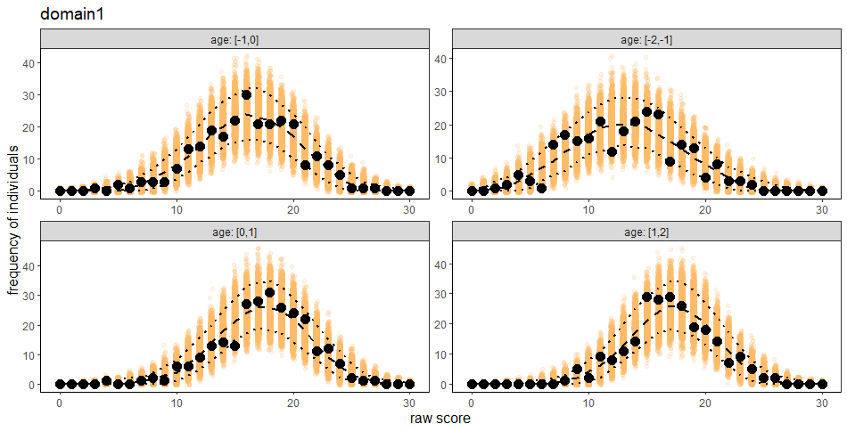

```r
NC_info_age <- raw_score_ppc(fit_info = infoHO, age_range = seq(-2,2,1))
visual_raw_score_ppc(NC_info_age, dim_plot = "general")
visual_raw_score_ppc(NC_info_age, dim_plot = "domain1")
```

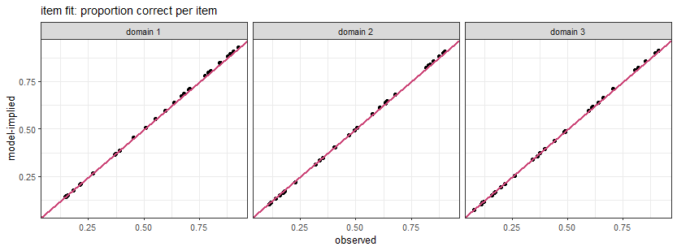

```r
item_person_fit(fit_info =infoHO, parameter = "item")
```

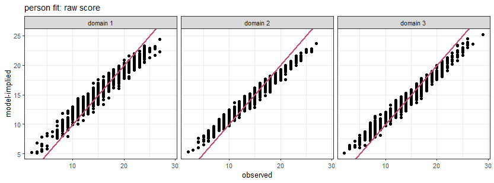

```r
item_person_fit(fit_info =infoHO, parameter = "person")
```

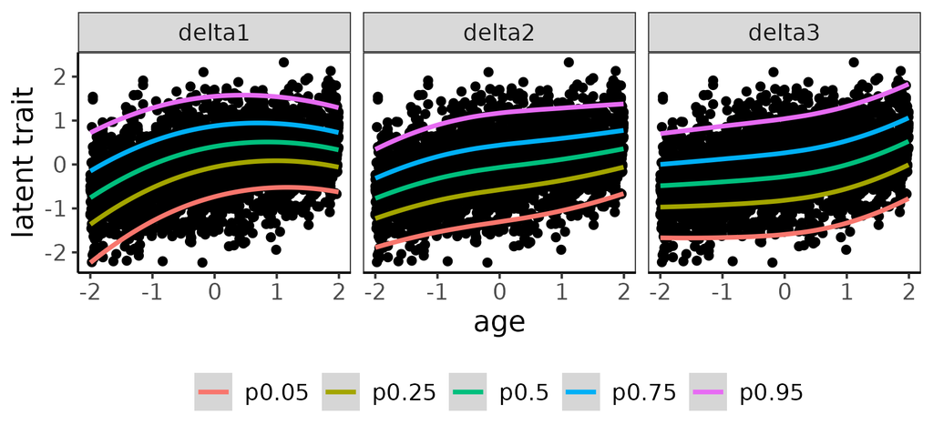

```r
quantile_curves(fit_info = infoHO, probs = c(0.05, 0.25, 0.5, 0.75, 0.95))
```

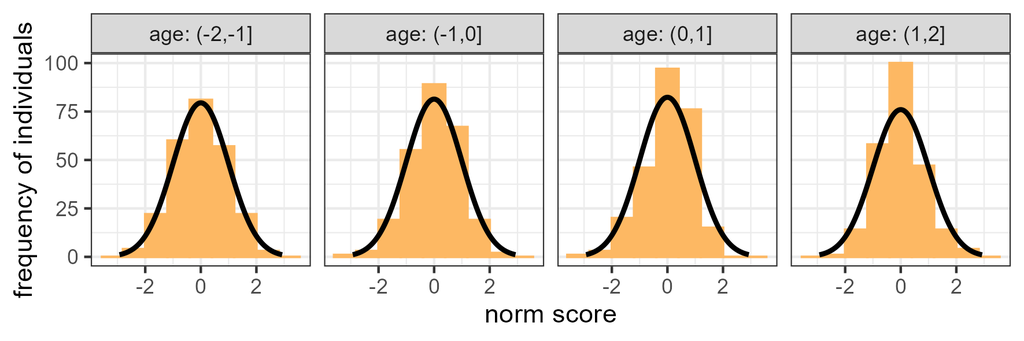

```r
normscore_dist(fit_info= infoHO, age_range = seq(5,21,4), binwidth = 0.8, dim_plot = "general")
```

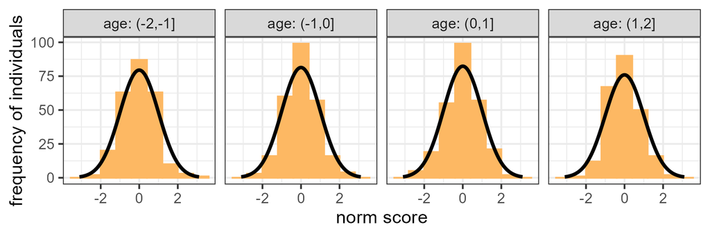

```r
normscore_dist(fit_info= infoHO, age_range = seq(5,21,4), binwidth = 0.8, dim_plot = "domain1")
```

```r
res_info <- item_residual_cor(fit_info = infoHO)
```

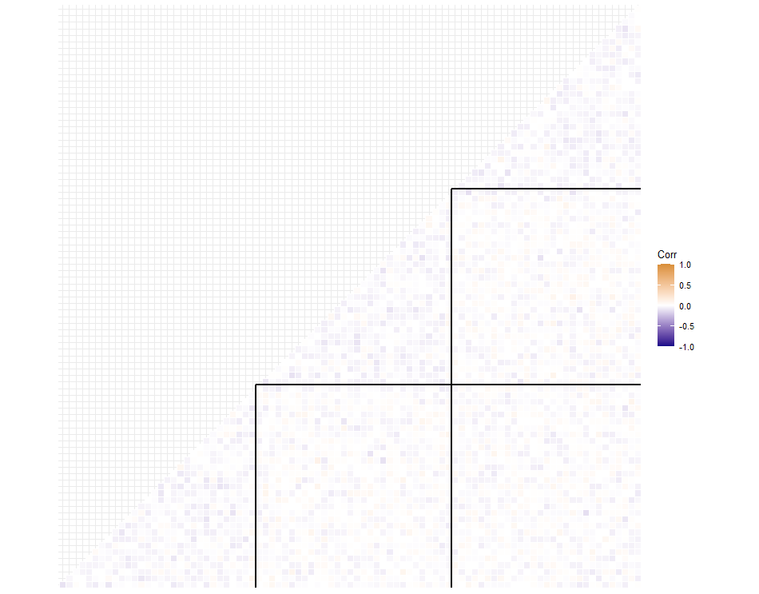

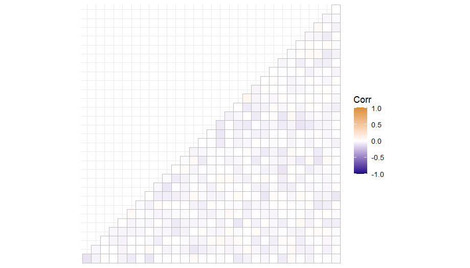

```r
item_residual_cor(fit_info = infoHO, domain = 1)
```

```r
cor_info <- cor_structure(fit_info = infoHO)
```

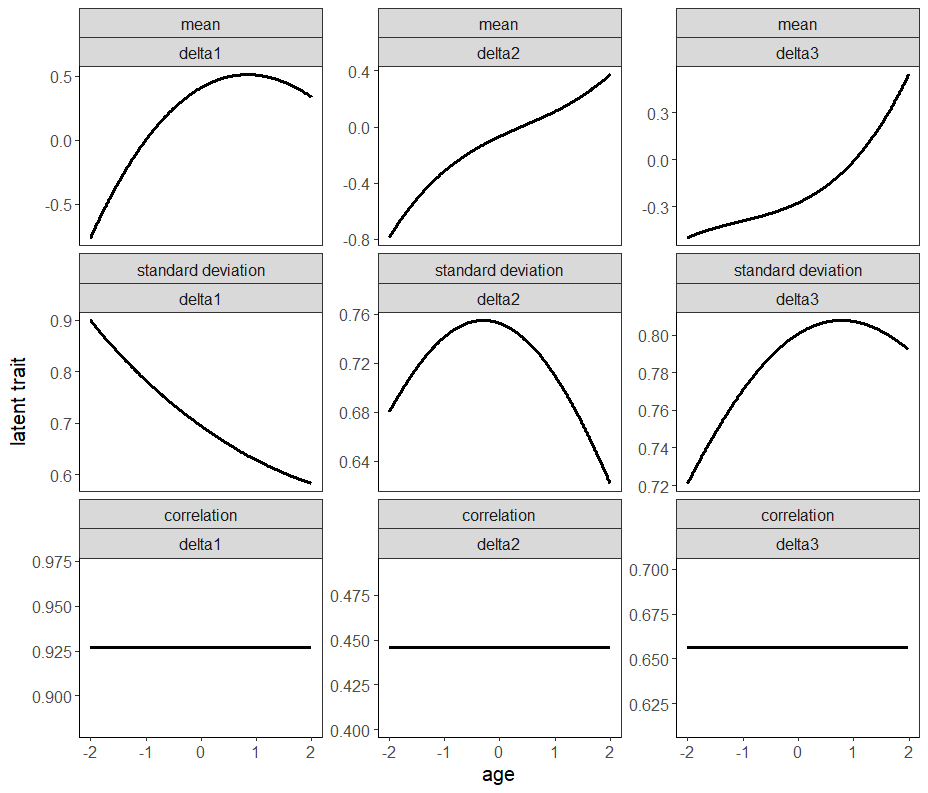

```r
effect_age(fit_info = infoHO)
```

To norm new individuals is similar

```r
y <- HOdata[65, 1:90]
age <- HOdata$age[65]

info_newperson <- norm_new_individual(new_y = y, new_age= age + 0.3,
                                      fit_info = infoHO)
```